# Artificial Intelligence Course 2024

#### Practical Considerations

- **Choosing the Dropout Rate**:
  - Typical values are between 0.2 and 0.5. It's often chosen through experimentation and cross-validation.
- **Application**:
  - Dropout can be applied to any layer in the neural network, but it is most commonly used in the fully connected layers.

```python
sequence_len = 64
twitter_dataset = Twitter(dataframe=data, w2v_model=w2v_model, sequence_len=sequence_len)

import numpy as np
twitter_dataset.seq_report()

print(twitter_dataset)

from sklearn.model_selection import train_test_split



train_df, valid_df = train_test_split(data, test_size=0.2, random_state=42)

train_dataset = Twitter(
    dataframe=train_df,
    w2v_model=w2v_model,
    sequence_len=sequence_len
)

valid_dataset = Twitter(
    dataframe=valid_df,
    w2v_model=w2v_model,
    sequence_len=sequence_len
)
```

```
Deleted 0-Len Samples: 32
```

```
Sequence Length Report
:::::MAX  LENGTH:::[ 64  ]
:::::MIN  LENGTH:::[ 64  ]
:::::MEAN LENGTH:::[64.0 ]
Sequence Tokenization Report
:::::All Unique Tokens:::[17092 ]
:::::All Valid Tokens:::[11901 ]
:::::Valid Tokens:::[69.63%]
<__main__.Twitter object at 0x7b3cf831c760>
Deleted 0-Len Samples: 24
```

```
Deleted 0-Len Samples: 8
```

```python
import torch
import torch.nn as nn
import torch.nn.functional as F

class CNN(nn.Module):
    def __init__(self):
        super(CNN, self).__init__()
        self.conv1_1 = nn.Conv1d(in_channels=300, out_channels=64, kernel_size=3, padding=1)
        self.bn1 = nn.BatchNorm1d(64)
        self.conv1_2 = nn.Conv1d(in_channels=64, out_channels=128, kernel_size=3, padding=1)
        self.bn2 = nn.BatchNorm1d(128)
        self.conv1_3 = nn.Conv1d(in_channels=128, out_channels=256, kernel_size=3, padding=1)
        self.bn3 = nn.BatchNorm1d(256)
        self.pool = nn.MaxPool1d(kernel_size=2, stride=2)
        self.dropout = nn.Dropout(p=0.5)
        self.fc1 = nn.Linear(256 * 8, 64)
        self.fc2 = nn.Linear(64, 1)

    def forward(self, x):
        x = x.transpose(1, 2)
        x = F.relu(self.bn1(self.conv1_1(x)))
        x = self.pool(x)
        x = F.relu(self.bn2(self.conv1_2(x)))
        x = self.pool(x)
        x = F.relu(self.bn3(self.conv1_3(x)))
        x = self.pool(x)
        x = x.view(x.size(0), -1)
        x = self.dropout(F.relu(self.fc1(x)))
        x = self.fc2(x)
        x = torch.sigmoid(x)
        return x
```

```
Epoch [1/30] Train Loss: 0.5906, Train Acc: 0.8471, Valid Loss: 0.5733, Valid Acc: 0.8756
```

```
Epoch [2/30] Train Loss: 0.5727, Train Acc: 0.8852, Valid Loss: 0.5742, Valid Acc: 0.8684
```

```
Epoch [3/30] Train Loss: 0.5655, Train Acc: 0.9033, Valid Loss: 0.5626, Valid Acc: 0.9064
```

```
Epoch [4/30] Train Loss: 0.5609, Train Acc: 0.9156, Valid Loss: 0.5641, Valid Acc: 0.8965
```

```
Epoch [5/30] Train Loss: 0.5572, Train Acc: 0.9234, Valid Loss: 0.5625, Valid Acc: 0.9069
```

```
Epoch [6/30] Train Loss: 0.5540, Train Acc: 0.9316, Valid Loss: 0.5699, Valid Acc: 0.9003
```

```
Epoch [7/30] Train Loss: 0.5532, Train Acc: 0.9349, Valid Loss: 0.5624, Valid Acc: 0.9119
```

```
Epoch [8/30] Train Loss: 0.5505, Train Acc: 0.9410, Valid Loss: 0.5619, Valid Acc: 0.9135
```

```
Epoch [9/30] Train Loss: 0.5490, Train Acc: 0.9447, Valid Loss: 0.5614, Valid Acc: 0.9152
```

```
Epoch [10/30] Train Loss: 0.5480, Train Acc: 0.9461, Valid Loss: 0.5607, Valid Acc: 0.9174
```

```
Epoch [11/30] Train Loss: 0.5467, Train Acc: 0.9498, Valid Loss: 0.5697, Valid Acc: 0.9064
```

```
Epoch [12/30] Train Loss: 0.5450, Train Acc: 0.9543, Valid Loss: 0.5681, Valid Acc: 0.9031
```

```
Epoch [13/30] Train Loss: 0.5446, Train Acc: 0.9550, Valid Loss: 0.5673, Valid Acc: 0.9108
```

```
Epoch [14/30] Train Loss: 0.5435, Train Acc: 0.9579, Valid Loss: 0.5632, Valid Acc: 0.9119
```

```
Epoch [15/30] Train Loss: 0.5424, Train Acc: 0.9601, Valid Loss: 0.5626, Valid Acc: 0.9163
```

```
Epoch [16/30] Train Loss: 0.5408, Train Acc: 0.9642, Valid Loss: 0.5605, Valid Acc: 0.9102
```

```
Epoch [17/30] Train Loss: 0.5406, Train Acc: 0.9655, Valid Loss: 0.5598, Valid Acc: 0.9202
```

```
Epoch [18/30] Train Loss: 0.5403, Train Acc: 0.9670, Valid Loss: 0.5624, Valid Acc: 0.9157
```

```
Epoch [19/30] Train Loss: 0.5385, Train Acc: 0.9704, Valid Loss: 0.5605, Valid Acc: 0.9174
```

```
Epoch [20/30] Train Loss: 0.5390, Train Acc: 0.9693, Valid Loss: 0.5622, Valid Acc: 0.9135
```

```
Epoch [21/30] Train Loss: 0.5387, Train Acc: 0.9707, Valid Loss: 0.5589, Valid Acc: 0.9196
```

```
Epoch [22/30] Train Loss: 0.5378, Train Acc: 0.9717, Valid Loss: 0.5652, Valid Acc: 0.9135
```

```
Epoch [23/30] Train Loss: 0.5377, Train Acc: 0.9724, Valid Loss: 0.5671, Valid Acc: 0.9113
```

```
Epoch [24/30] Train Loss: 0.5371, Train Acc: 0.9736, Valid Loss: 0.5620, Valid Acc: 0.9213
```

```
Epoch [25/30] Train Loss: 0.5383, Train Acc: 0.9711, Valid Loss: 0.5651, Valid Acc: 0.9141
```

```
Epoch [26/30] Train Loss: 0.5375, Train Acc: 0.9736, Valid Loss: 0.5593, Valid Acc: 0.9152
```

```
Epoch [27/30] Train Loss: 0.5363, Train Acc: 0.9763, Valid Loss: 0.5599, Valid Acc: 0.9235
```

```
Epoch [28/30] Train Loss: 0.5368, Train Acc: 0.9751, Valid Loss: 0.5613, Valid Acc: 0.9152
```

```
Epoch [29/30] Train Loss: 0.5355, Train Acc: 0.9774, Valid Loss: 0.5617, Valid Acc: 0.9157
```

```
Epoch [30/30] Train Loss: 0.5354, Train Acc: 0.9785, Valid Loss: 0.5607, Valid Acc: 0.9196
```

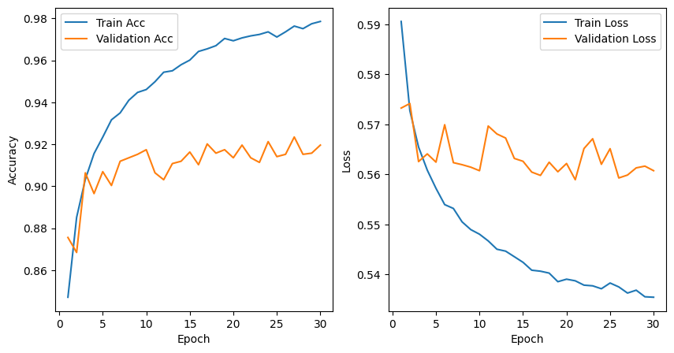

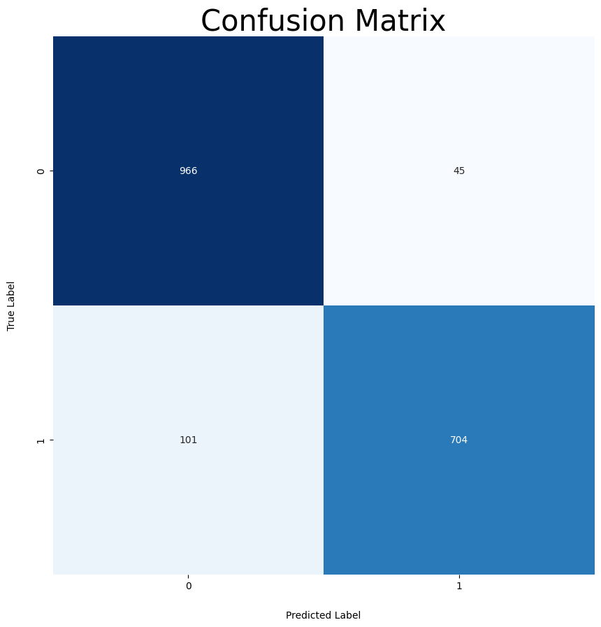

```
Recall:    0.915
F1:        0.918
Precision: 0.923
              precision    recall  f1-score   support

           0       0.91      0.96      0.93      1011
           1       0.94      0.87      0.91       805

    accuracy                           0.92      1816
   macro avg       0.92      0.92      0.92      1816
weighted avg       0.92      0.92      0.92      1816
```

```python
model = CNN()
batch_size = 16
loss_function = nn.BCEWithLogitsLoss()
optimizer = torch.optim.SGD(model.parameters(), lr=0.01, momentum=0.9, nesterov=True)
epochs = 30
device = 'auto'

cnn_model_train_history = train_model(
    model=model,
    batch_size=batch_size,
    loss_function=loss_function,
    optimizer=optimizer,
    epochs=epochs,
    train_set=train_dataset,
    valid_set=valid_dataset,
    device=device
)

trend_plot_helper(
    {
        "Accuracy - Epoch": [
            ("Train Acc", cnn_model_train_history["train_acc"]),
            ("Validation Acc", cnn_model_train_history["valid_acc"]),
        ],
        "Loss - Epoch": [
            ("Train Loss", cnn_model_train_history["train_loss"]),
            ("Validation Loss", cnn_model_train_history["valid_loss"])
        ]
    }
)

cnn_model_report = generate_confusion_matrix(
    model=model,
    dataset=valid_dataset,
)

print(f"Recall:    {cnn_model_report['recall']:.3f}")
print(f"F1:        {cnn_model_report['f1']:.3f}")
print(f"Precision: {cnn_model_report['precision']:.3f}")
print(cnn_model_report['report'])
```

```
Epoch [1/20] Train Loss: 0.6271, Train Acc: 0.8179, Valid Loss: 0.5896, Valid Acc: 0.8442
```

```
Epoch [2/20] Train Loss: 0.5932, Train Acc: 0.8405, Valid Loss: 0.5849, Valid Acc: 0.8475
```

```
Epoch [3/20] Train Loss: 0.5904, Train Acc: 0.8424, Valid Loss: 0.5827, Valid Acc: 0.8563
```

```
Epoch [4/20] Train Loss: 0.5874, Train Acc: 0.8483, Valid Loss: 0.5821, Valid Acc: 0.8541
```

```
Epoch [5/20] Train Loss: 0.5863, Train Acc: 0.8495, Valid Loss: 0.5810, Valid Acc: 0.8585
```

```
Epoch [6/20] Train Loss: 0.5849, Train Acc: 0.8526, Valid Loss: 0.5801, Valid Acc: 0.8601
```

```
Epoch [7/20] Train Loss: 0.5834, Train Acc: 0.8583, Valid Loss: 0.5791, Valid Acc: 0.8640
```

```
Epoch [8/20] Train Loss: 0.5811, Train Acc: 0.8634, Valid Loss: 0.5780, Valid Acc: 0.8656
```

```
Epoch [9/20] Train Loss: 0.5804, Train Acc: 0.8663, Valid Loss: 0.5768, Valid Acc: 0.8700
```

```
Epoch [10/20] Train Loss: 0.5778, Train Acc: 0.8725, Valid Loss: 0.5757, Valid Acc: 0.8695
```

```
Epoch [11/20] Train Loss: 0.5766, Train Acc: 0.8755, Valid Loss: 0.5738, Valid Acc: 0.8750
```

```
Epoch [12/20] Train Loss: 0.5749, Train Acc: 0.8794, Valid Loss: 0.5720, Valid Acc: 0.8822
```

```
Epoch [13/20] Train Loss: 0.5719, Train Acc: 0.8880, Valid Loss: 0.5706, Valid Acc: 0.8877
```

```
Epoch [14/20] Train Loss: 0.5712, Train Acc: 0.8896, Valid Loss: 0.5695, Valid Acc: 0.8921
```

```
Epoch [15/20] Train Loss: 0.5685, Train Acc: 0.8967, Valid Loss: 0.5682, Valid Acc: 0.8932
```

```
Epoch [16/20] Train Loss: 0.5669, Train Acc: 0.9008, Valid Loss: 0.5672, Valid Acc: 0.8965
```

```
Epoch [17/20] Train Loss: 0.5653, Train Acc: 0.9057, Valid Loss: 0.5660, Valid Acc: 0.8987
```

```
Epoch [18/20] Train Loss: 0.5632, Train Acc: 0.9099, Valid Loss: 0.5653, Valid Acc: 0.9047
```

```
Epoch [19/20] Train Loss: 0.5621, Train Acc: 0.9145, Valid Loss: 0.5644, Valid Acc: 0.9042
```

```
Epoch [20/20] Train Loss: 0.5606, Train Acc: 0.9179, Valid Loss: 0.5643, Valid Acc: 0.9053
```

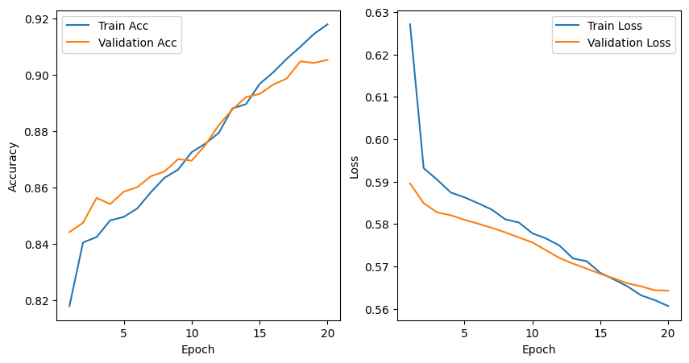

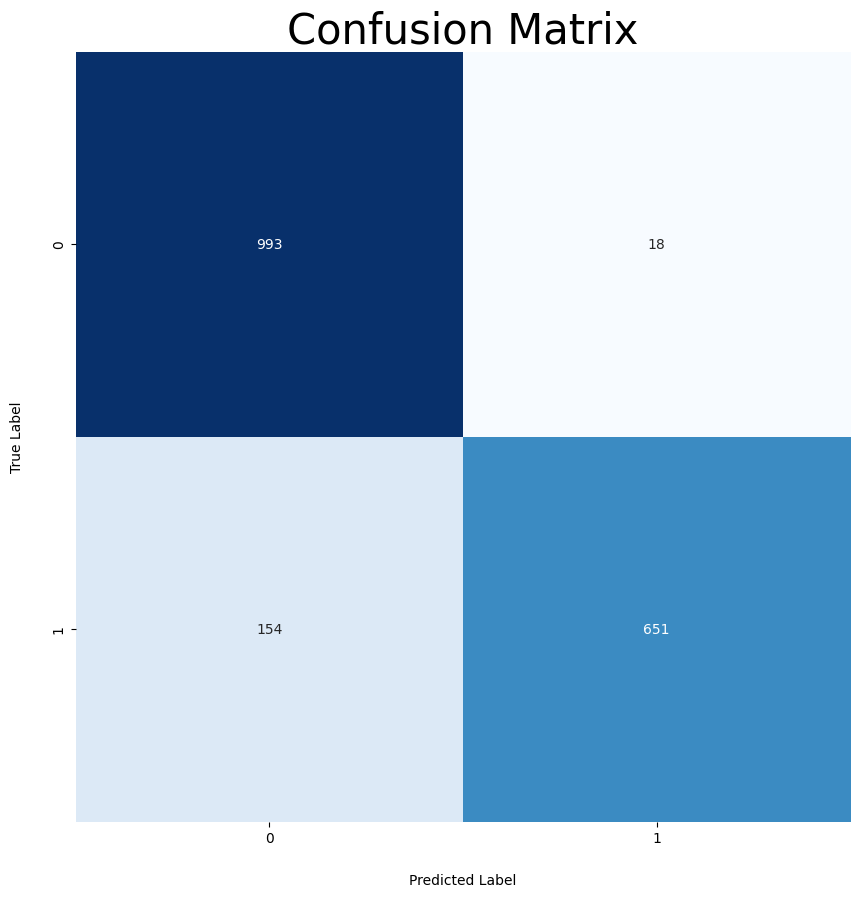

```
Recall:    0.895
F1:        0.902
Precision: 0.919
              precision    recall  f1-score   support

           0       0.87      0.98      0.92      1011
           1       0.97      0.81      0.88       805

    accuracy                           0.91      1816
   macro avg       0.92      0.90      0.90      1816
weighted avg       0.91      0.91      0.90      1816
```

```python
import torch
import torch.nn as nn
import torch.optim as optim
import torch.nn.functional as F
model = CNN()


batch_size = 30
loss_function = nn.BCEWithLogitsLoss()
optimizer = torch.optim.SGD(model.parameters(), lr=0.001, momentum=0.9, nesterov=True)


epochs = 20
device = 'auto'

cnn_model_train_history = train_model(
    model=model,
    batch_size=batch_size,
    loss_function=loss_function,
    optimizer=optimizer,
    epochs=epochs,
    train_set=train_dataset,
    valid_set=valid_dataset,
    device=device
)

trend_plot_helper(
    {
        "Accuracy - Epoch": [
            ("Train Acc", cnn_model_train_history["train_acc"]),
            ("Validation Acc", cnn_model_train_history["valid_acc"]),
        ],
        "Loss - Epoch": [
            ("Train Loss", cnn_model_train_history["train_loss"]),
            ("Validation Loss", cnn_model_train_history["valid_loss"])
        ]
    }
)

cnn_model_report = generate_confusion_matrix(
    model=model,
    dataset=valid_dataset,
)


print(f"Recall:    {cnn_model_report['recall']:.3f}")
print(f"F1:        {cnn_model_report['f1']:.3f}")
print(f"Precision: {cnn_model_report['precision']:.3f}")
print(cnn_model_report['report'])
```

```
Epoch [1/20] Train Loss: 0.5838, Train Acc: 0.8578, Valid Loss: 0.5696, Valid Acc: 0.8855
```

```
Epoch [2/20] Train Loss: 0.5726, Train Acc: 0.8834, Valid Loss: 0.5689, Valid Acc: 0.8981
```

```
Epoch [3/20] Train Loss: 0.5657, Train Acc: 0.9033, Valid Loss: 0.5746, Valid Acc: 0.8695
```

```
Epoch [4/20] Train Loss: 0.5617, Train Acc: 0.9124, Valid Loss: 0.5738, Valid Acc: 0.8706
```

```
Epoch [5/20] Train Loss: 0.5601, Train Acc: 0.9167, Valid Loss: 0.5625, Valid Acc: 0.9058
```

```
Epoch [6/20] Train Loss: 0.5552, Train Acc: 0.9275, Valid Loss: 0.5693, Valid Acc: 0.9042
```

```
Epoch [7/20] Train Loss: 0.5552, Train Acc: 0.9281, Valid Loss: 0.5634, Valid Acc: 0.9091
```

```
Epoch [8/20] Train Loss: 0.5531, Train Acc: 0.9337, Valid Loss: 0.5701, Valid Acc: 0.9031
```

```
Epoch [9/20] Train Loss: 0.5511, Train Acc: 0.9371, Valid Loss: 0.5665, Valid Acc: 0.8959
```

```
Epoch [10/20] Train Loss: 0.5525, Train Acc: 0.9360, Valid Loss: 0.5647, Valid Acc: 0.8992
```

```
Epoch [11/20] Train Loss: 0.5514, Train Acc: 0.9377, Valid Loss: 0.5628, Valid Acc: 0.9113
```

```
Epoch [12/20] Train Loss: 0.5500, Train Acc: 0.9433, Valid Loss: 0.5613, Valid Acc: 0.9146
```

```
Epoch [13/20] Train Loss: 0.5513, Train Acc: 0.9402, Valid Loss: 0.5648, Valid Acc: 0.9135
```

```
Epoch [14/20] Train Loss: 0.5495, Train Acc: 0.9433, Valid Loss: 0.5625, Valid Acc: 0.9146
```

```
Epoch [15/20] Train Loss: 0.5485, Train Acc: 0.9453, Valid Loss: 0.5596, Valid Acc: 0.9130
```

```
Epoch [16/20] Train Loss: 0.5465, Train Acc: 0.9509, Valid Loss: 0.5721, Valid Acc: 0.8992
```

```
Epoch [17/20] Train Loss: 0.5473, Train Acc: 0.9477, Valid Loss: 0.5651, Valid Acc: 0.9113
```

```
Epoch [18/20] Train Loss: 0.5451, Train Acc: 0.9519, Valid Loss: 0.5713, Valid Acc: 0.9025
```

```
Epoch [19/20] Train Loss: 0.5478, Train Acc: 0.9482, Valid Loss: 0.5640, Valid Acc: 0.9025
```

```
Epoch [20/20] Train Loss: 0.5469, Train Acc: 0.9475, Valid Loss: 0.5645, Valid Acc: 0.9025
```

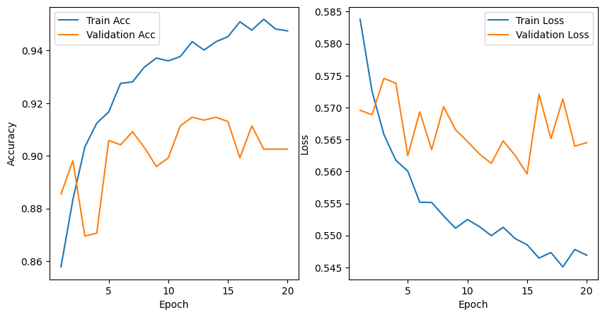

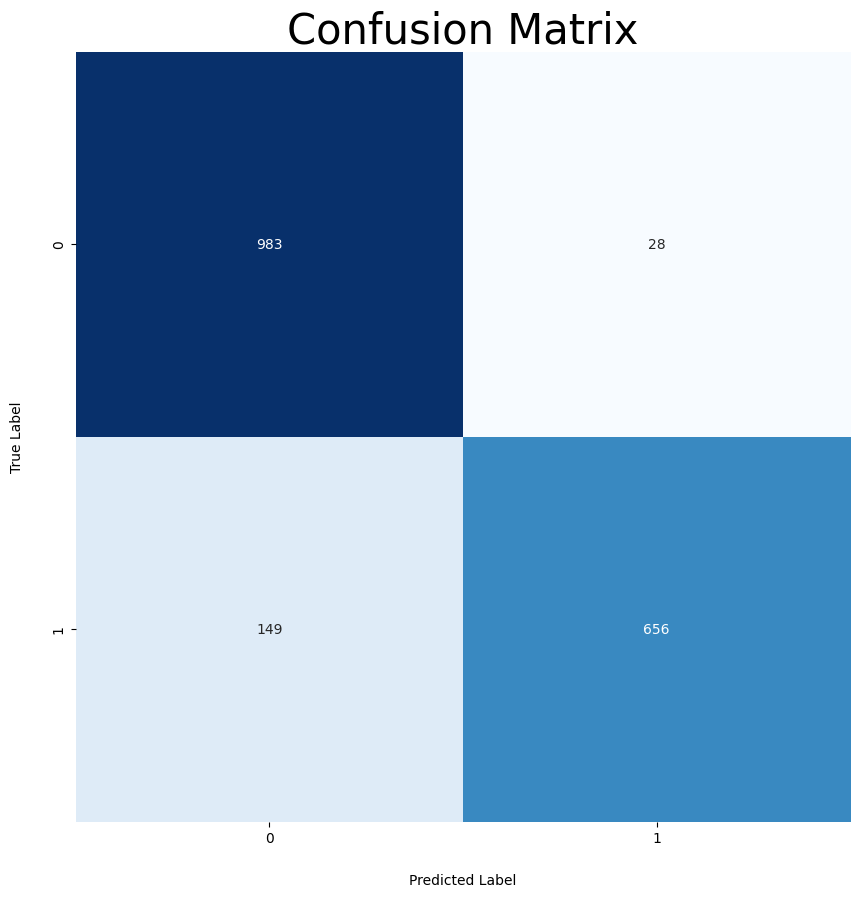

```
Recall:    0.894
F1:        0.899
Precision: 0.914
              precision    recall  f1-score   support

           0       0.87      0.97      0.92      1011
           1       0.96      0.81      0.88       805

    accuracy                           0.90      1816
   macro avg       0.91      0.89      0.90      1816
weighted avg       0.91      0.90      0.90      1816
```

```python
import torch
import torch.nn as nn
import torch.optim as optim
import torch.nn.functional as F

model = CNN()

batch_size = 60
loss_function = nn.BCEWithLogitsLoss()
optimizer = torch.optim.AdamW(model.parameters(), lr=0.001, betas=(0.9, 0.999), weight_decay=0.01)


epochs = 20
device = 'auto'

cnn_model_train_history = train_model(
    model=model,
    batch_size=batch_size,
    loss_function=loss_function,
    optimizer=optimizer,
    epochs=epochs,
    train_set=train_dataset,
    valid_set=valid_dataset,
    device=device
)

trend_plot_helper(
    {
        "Accuracy - Epoch": [
            ("Train Acc", cnn_model_train_history["train_acc"]),
            ("Validation Acc", cnn_model_train_history["valid_acc"]),
        ],
        "Loss - Epoch": [
            ("Train Loss", cnn_model_train_history["train_loss"]),
            ("Validation Loss", cnn_model_train_history["valid_loss"])
        ]
    }
)

cnn_model_report = generate_confusion_matrix(
    model=model,
    dataset=valid_dataset,
)


print(f"Recall:    {cnn_model_report['recall']:.3f}")
print(f"F1:        {cnn_model_report['f1']:.3f}")
print(f"Precision: {cnn_model_report['precision']:.3f}")
print(cnn_model_report['report'])
```

we can see that with Batch normalization we can have more non overfitted model and we have better models with less epochs and less computational cost

resourses :

https://radimrehurek.com/gensim/models/word2vec.html

https://en.wikipedia.org/wiki/Gensim#:~:text=Gensim%20is%20an%20open%2Dsource,using%20modern%20statistical%20machine%20learning.

https://aws.amazon.com/what-is/recurrent-neural-network/#:~:text=A%20recurrent%20neural%20network%20(RNN,complex%20semantics%20and%20syntax%20rules.

https://www.jmlr.org/papers/volume3/blei03a/blei03a.pdf

https://en.wikipedia.org/wiki/Sparse_approximation

https://en.wikipedia.org/wiki/Word2vec#:~:text=Word2vec%20is%20a%20technique%20in,text%20in%20a%20large%20corpus.

https://www.tensorflow.org/text/tutorials/word2vec

https://data-hub.ir/%D8%A7%D9%84%DA%AF%D9%88%D8%B1%DB%8C%D8%AA%D9%85-word2vec-%DA%86%DB%8C%D8%B3%D8%AA/#elementor-toc__heading-anchor-3

https://jalammar.github.io/illustrated-word2vec/

https://machinelearningmastery.com/adam-optimization-algorithm-for-deep-learning/

https://www.tutorialspoint.com/google_colab/index.htm

https://colab.research.google.com/notebooks/intro.ipynb

https://machinelearningmastery.com/introduction-to-regularization-to-reduce-overfitting-and-improve-generalization-error/